# Assignment 2 FUNDAMENTALS OF MACHINE LEARNING

Brian Yim

2025-09-27

#### 1. Age = 40, Experience = 10, Income = 84, Family = 2, CCAvg = 2, Education_1 = 0, Education_2 = 1, Education_3 = 0, Mortgage = 0, Securities Account = 0, CD Account = 0, Online = 1, and Credit Card = 1. Perform a k-NN classification with all predictors except ID and ZIP code using k = 1. Remember to transform categorical predictors with more than two categories into dummy variables first. Specify the success class as 1 (loan acceptance), and use the default cutoff value of 0.5. How would this customer be classified?

```r
library(readr)
library(class)
library(caret)
library(dplyr)
library("gmodels")
```

#reading the data and creating the working dataset

```r
UniversalBank <- read.csv("C:/Users/hyim/OneDrive - Kent State University/Desktop/64060 Assignment2/UniversalBank.csv")
mydata=data.frame(UniversalBank, header=T, stringsAsFactors=TRUE) # Create the working data set, converting data to factor
View(mydata)
```

#check the characteristics and quality of the data

```r
table(is.na(mydata)) #Find if any missing data
```

```
##
## FALSE
## 75000
```

```r
data.frame(colnames(mydata)) #Returns column index in the original data
```

```
##      colnames.mydata.
## 1                  ID
## 2                 Age
## 3          Experience
## 4              Income
## 5            ZIP.Code
## 6              Family
## 7               CCAvg
## 8           Education
## 9            Mortgage
## 10      Personal.Loan
## 11 Securities.Account
## 12         CD.Account
## 13             Online
## 14         CreditCard
## 15             header
```

```r
summary(mydata)
```

```
##        ID            Age          Experience       Income          ZIP.Code
##  Min.   :   1   Min.   :23.00   Min.   :-3.0   Min.   :  8.00   Min.   : 9307
##  1st Qu.:1251   1st Qu.:35.00   1st Qu.:10.0   1st Qu.: 39.00   1st Qu.:91911
##  Median :2500   Median :45.00   Median :20.0   Median : 64.00   Median :93437
##  Mean   :2500   Mean   :45.34   Mean   :20.1   Mean   : 73.77   Mean   :93153
##  3rd Qu.:3750   3rd Qu.:55.00   3rd Qu.:30.0   3rd Qu.: 98.00   3rd Qu.:94608
##  Max.   :5000   Max.   :67.00   Max.   :43.0   Max.   :224.00   Max.   :96651
##      Family          CCAvg          Education        Mortgage
##  Min.   :1.000   Min.   : 0.000   Min.   :1.000   Min.   :  0.0
##  1st Qu.:1.000   1st Qu.: 0.700   1st Qu.:1.000   1st Qu.:  0.0
##  Median :2.000   Median : 1.500   Median :2.000   Median :  0.0
##  Mean   :2.396   Mean   : 1.938   Mean   :1.881   Mean   : 56.5
##  3rd Qu.:3.000   3rd Qu.: 2.500   3rd Qu.:3.000   3rd Qu.:101.0
##  Max.   :4.000   Max.   :10.000   Max.   :3.000   Max.   :635.0
##  Personal.Loan   Securities.Account   CD.Account         Online
##  Min.   :0.000   Min.   :0.0000     Min.   :0.0000   Min.   :0.0000
##  1st Qu.:0.000   1st Qu.:0.0000     1st Qu.:0.0000   1st Qu.:0.0000
##  Median :0.000   Median :0.0000     Median :0.0000   Median :1.0000
##  Mean   :0.096   Mean   :0.1044     Mean   :0.0604   Mean   :0.5968
##  3rd Qu.:0.000   3rd Qu.:0.0000     3rd Qu.:0.0000   3rd Qu.:1.0000
##  Max.   :1.000   Max.   :1.0000     Max.   :1.0000   Max.   :1.0000
##    CreditCard     header
##  Min.   :0.000   Mode:logical
##  1st Qu.:0.000   TRUE:5000
##  Median :0.000
##  Mean   :0.294
##  3rd Qu.:1.000
##  Max.   :1.000
```

#manipulate the data

```r
mydata<-mydata[c(-1,-5)] #Remove ID and Zip code
data.frame(colnames(mydata)) #Returns column index after removing two columns
```

```
##      colnames.mydata.
## 1                 Age
## 2          Experience
## 3              Income
## 4              Family
## 5               CCAvg
## 6           Education
## 7            Mortgage
## 8       Personal.Loan
## 9  Securities.Account
## 10         CD.Account
## 11             Online
## 12         CreditCard
## 13             header
```

#dummy Variables (Education_1, Education_2, Education_3) for categorial variable (Education)

```r
mydata$Education_1<-mydata$Education
mydata$Education_1[mydata$Education==1]<-1
mydata$Education_1[mydata$Education==2|mydata$Education==3]<-0

mydata$Education_2<-mydata$Education
mydata$Education_2[mydata$Education==2]<-1
mydata$Education_2[mydata$Education==1|mydata$Education==3]<-0

mydata$Education_3<-mydata$Education
mydata$Education_3[mydata$Education==3]<-1
mydata$Education_3[mydata$Education==1|mydata$Education==2]<-0

mydata<-mydata[,-6] #Remove Education column to count double effect

#Convert the "Personal Loan" Success class as Yes and Fail Class for readability
mydata$Personal.Loan [mydata$Personal.Loan==1]<-"Success"
mydata$Personal.Loan [mydata$Personal.Loan==0]<-"Fail"

#Move the Label column (the goal of the research), Personal Loan, to a first position.
mydata<-mydata%>%relocate(c(Personal.Loan))
data.frame(colnames(mydata)) #Returns column index to check the result
```

```
##      colnames.mydata.
## 1       Personal.Loan
## 2                 Age
## 3          Experience
## 4              Income
## 5              Family
## 6               CCAvg
## 7            Mortgage
## 8  Securities.Account
## 9          CD.Account
## 10             Online
## 11         CreditCard
## 12             header
## 13        Education_1
## 14        Education_2
## 15        Education_3
```

```r
str(mydata)
```

```
## 'data.frame':    5000 obs. of  15 variables:
##  $ Personal.Loan     : chr  "Fail" "Fail" "Fail" "Fail" ...
##  $ Age               : int  25 45 39 35 35 37 53 50 35 34 ...
##  $ Experience        : int  1 19 15 9 8 13 27 24 10 9 ...
##  $ Income            : int  49 34 11 100 45 29 72 22 81 180 ...
##  $ Family            : int  4 3 1 1 4 4 2 1 3 1 ...
##  $ CCAvg             : num  1.6 1.5 1 2.7 1 0.4 1.5 0.3 0.6 8.9 ...
##  $ Mortgage          : int  0 0 0 0 0 155 0 0 104 0 ...
##  $ Securities.Account: int  1 1 0 0 0 0 0 0 0 0 ...
##  $ CD.Account        : int  0 0 0 0 0 0 0 0 0 0 ...
##  $ Online            : int  0 0 0 0 0 1 1 0 1 0 ...
##  $ CreditCard        : int  0 0 0 0 1 0 0 1 0 0 ...
##  $ header            : logi  TRUE TRUE TRUE TRUE TRUE TRUE ...
##  $ Education_1       : num  1 1 1 0 0 0 0 0 0 0 ...
##  $ Education_2       : num  0 0 0 1 1 1 1 0 1 0 ...
##  $ Education_3       : num  0 0 0 0 0 0 0 1 0 1 ...
```

#dividing the data into training (60%) and validation (40%) data sets

```r
set.seed(200)
Train_Index_q1=createDataPartition(mydata$Personal.Loan, p=0.6, list=FALSE) #Create an index for the training sample (60% of the dataset)
Train_Data_q1=mydata[Train_Index_q1,] #Create the training dataset using the index of the training sample
Validation_Data_q1=mydata[-Train_Index_q1,] #Create the validation dataset using the reverse index of the training sample (40% of the dataset)
#Summarize both datasets to ensure the summary statistics are similar.
summary(Train_Data_q1)
```

```
##  Personal.Loan           Age          Experience        Income
##  Length:3000        Min.   :23.00   Min.   :-3.00   Min.   :  8.00
##  Class :character   1st Qu.:35.00   1st Qu.:10.00   1st Qu.: 39.00
##  Mode  :character   Median :45.00   Median :20.00   Median : 63.00
##                     Mean   :45.24   Mean   :19.99   Mean   : 73.31
##                     3rd Qu.:55.00   3rd Qu.:30.00   3rd Qu.: 98.00
##                     Max.   :67.00   Max.   :43.00   Max.   :224.00
##      Family          CCAvg           Mortgage      Securities.Account
##  Min.   :1.000   Min.   : 0.000   Min.   :  0.00   Min.   :0.0000
##  1st Qu.:1.000   1st Qu.: 0.700   1st Qu.:  0.00   1st Qu.:0.0000
##  Median :2.000   Median : 1.500   Median :  0.00   Median :0.0000
##  Mean   :2.412   Mean   : 1.934   Mean   : 55.34   Mean   :0.1007
##  3rd Qu.:3.000   3rd Qu.: 2.500   3rd Qu.: 98.25   3rd Qu.:0.0000
##  Max.   :4.000   Max.   :10.000   Max.   :617.00   Max.   :1.0000
##    CD.Account          Online        CreditCard      header
##  Min.   :0.00000   Min.   :0.000   Min.   :0.0000   Mode:logical
##  1st Qu.:0.00000   1st Qu.:0.000   1st Qu.:0.0000   TRUE:3000
##  Median :0.00000   Median :1.000   Median :0.0000
##  Mean   :0.05667   Mean   :0.594   Mean   :0.2927
##  3rd Qu.:0.00000   3rd Qu.:1.000   3rd Qu.:1.0000
##  Max.   :1.00000   Max.   :1.000   Max.   :1.0000
##   Education_1     Education_2      Education_3
##  Min.   :0.000   Min.   :0.0000   Min.   :0.0000
##  1st Qu.:0.000   1st Qu.:0.0000   1st Qu.:0.0000
##  Median :0.000   Median :0.0000   Median :0.0000
##  Mean   :0.411   Mean   :0.2827   Mean   :0.3063
##  3rd Qu.:1.000   3rd Qu.:1.0000   3rd Qu.:1.0000
##  Max.   :1.000   Max.   :1.0000   Max.   :1.0000
```

```r
summary(Validation_Data_q1)
```

```
##  Personal.Loan           Age          Experience        Income
##  Length:2000        Min.   :23.00   Min.   :-3.00   Min.   :  8.00
##  Class :character   1st Qu.:36.00   1st Qu.:10.00   1st Qu.: 39.00
##  Mode  :character   Median :46.00   Median :20.00   Median : 64.00
##                     Mean   :45.49   Mean   :20.28   Mean   : 74.47
##                     3rd Qu.:55.00   3rd Qu.:30.00   3rd Qu.:101.00
##                     Max.   :67.00   Max.   :43.00   Max.   :205.00
##      Family          CCAvg           Mortgage      Securities.Account
##  Min.   :1.000   Min.   : 0.000   Min.   :  0.00   Min.   :0.00
##  1st Qu.:1.000   1st Qu.: 0.700   1st Qu.:  0.00   1st Qu.:0.00
##  Median :2.000   Median : 1.600   Median :  0.00   Median :0.00
##  Mean   :2.373   Mean   : 1.943   Mean   : 58.23   Mean   :0.11
##  3rd Qu.:3.000   3rd Qu.: 2.600   3rd Qu.:103.00   3rd Qu.:0.00
##  Max.   :4.000   Max.   :10.000   Max.   :635.00   Max.   :1.00
##    CD.Account        Online        CreditCard     header
##  Min.   :0.000   Min.   :0.000   Min.   :0.000   Mode:logical
##  1st Qu.:0.000   1st Qu.:0.000   1st Qu.:0.000   TRUE:2000
##  Median :0.000   Median :1.000   Median :0.000
##  Mean   :0.066   Mean   :0.601   Mean   :0.296
##  3rd Qu.:0.000   3rd Qu.:1.000   3rd Qu.:1.000
##  Max.   :1.000   Max.   :1.000   Max.   :1.000
##   Education_1      Education_2      Education_3
##  Min.   :0.0000   Min.   :0.0000   Min.   :0.000
##  1st Qu.:0.0000   1st Qu.:0.0000   1st Qu.:0.000
##  Median :0.0000   Median :0.0000   Median :0.000
##  Mean   :0.4315   Mean   :0.2775   Mean   :0.291
##  3rd Qu.:1.0000   3rd Qu.:1.0000   3rd Qu.:1.000
##  Max.   :1.0000   Max.   :1.0000   Max.   :1.000
```

#data Normalization on the Train set and apply it to the Validation set.(z-score scaling using “center” and “scale” as input method parameters.)

```r
#Copy the original data
Train_Norm_q1<-Train_Data_q1
Validation_Norm_q1<-Validation_Data_q1

# Normalizing the data sets
normq1<-preProcess(Train_Data_q1,method=c("center", "scale"))
Train_Norm_q1<-predict(normq1, Train_Data_q1)
Validation_Norm_q1<-predict(normq1, Validation_Data_q1)

# Check the mean and variance of variables in the Training set (expected 0 and 1, respectively)
summary(Train_Norm_q1)
```

```
##  Personal.Loan           Age            Experience            Income
##  Length:3000        Min.   :-1.9326   Min.   :-2.002298   Min.   :-1.4231
##  Class :character   1st Qu.:-0.8898   1st Qu.:-0.869990   1st Qu.:-0.7477
##  Mode  :character   Median :-0.0208   Median : 0.001016   Median :-0.2247
##                     Mean   : 0.0000   Mean   : 0.000000   Mean   : 0.0000
##                     3rd Qu.: 0.8482   3rd Qu.: 0.872022   3rd Qu.: 0.5379
##                     Max.   : 1.8910   Max.   : 2.004330   Max.   : 3.2833
##      Family            CCAvg            Mortgage       Securities.Account
##  Min.   :-1.2343   Min.   :-1.0966   Min.   :-0.5496   Min.   :-0.3345
##  1st Qu.:-1.2343   1st Qu.:-0.6998   1st Qu.:-0.5496   1st Qu.:-0.3345
##  Median :-0.3600   Median :-0.2462   Median :-0.5496   Median :-0.3345
##  Mean   : 0.0000   Mean   : 0.0000   Mean   : 0.0000   Mean   : 0.0000
##  3rd Qu.: 0.5144   3rd Qu.: 0.3207   3rd Qu.: 0.4260   3rd Qu.:-0.3345
##  Max.   : 1.3888   Max.   : 4.5728   Max.   : 5.5773   Max.   : 2.9884
##    CD.Account          Online          CreditCard       header
##  Min.   :-0.2451   Min.   :-1.2094   Min.   :-0.6431   Mode:logical
##  1st Qu.:-0.2451   1st Qu.:-1.2094   1st Qu.:-0.6431   TRUE:3000
##  Median :-0.2451   Median : 0.8266   Median :-0.6431
##  Mean   : 0.0000   Mean   : 0.0000   Mean   : 0.0000
##  3rd Qu.:-0.2451   3rd Qu.: 0.8266   3rd Qu.: 1.5544
##  Max.   : 4.0794   Max.   : 0.8266   Max.   : 1.5544
##   Education_1       Education_2       Education_3
##  Min.   :-0.8352   Min.   :-0.6276   Min.   :-0.6644
##  1st Qu.:-0.8352   1st Qu.:-0.6276   1st Qu.:-0.6644
##  Median :-0.8352   Median :-0.6276   Median :-0.6644
##  Mean   : 0.0000   Mean   : 0.0000   Mean   : 0.0000
##  3rd Qu.: 1.1969   3rd Qu.: 1.5928   3rd Qu.: 1.5045
##  Max.   : 1.1969   Max.   : 1.5928   Max.   : 1.5045
```

```r
var(Train_Norm_q1[,2:14])
```

```
##                             Age   Experience        Income        Family
## Age                 1.000000000  0.994051331 -0.0541805855 -0.0459752949
## Experience          0.994051331  1.000000000 -0.0469553336 -0.0518714009
## Income             -0.054180585 -0.046955334  1.0000000000 -0.1386275054
## Family             -0.045975295 -0.051871401 -0.1386275054  1.0000000000
## CCAvg              -0.053978539 -0.051819986  0.6520009769 -0.0830325158
## Mortgage            0.004347544  0.007189289  0.1934238425 -0.0287929211
## Securities.Account -0.003974638 -0.005740051  0.0009240143  0.0345647885
## CD.Account          0.011692905  0.013562278  0.1505197849  0.0063251619
## Online              0.023451183  0.024172211  0.0144823824  0.0079602253
## CreditCard          0.016101477  0.017311421 -0.0174571468  0.0003566558
## header              0.000000000  0.000000000  0.0000000000  0.0000000000
## Education_1        -0.022970492  0.001557223  0.2135701280 -0.1135104295
## Education_2        -0.036863586 -0.037216080 -0.1277834990  0.1358880445
##                            CCAvg     Mortgage Securities.Account   CD.Account
## Age                -5.397854e-02  0.004347544      -0.0039746381  0.011692905
## Experience         -5.181999e-02  0.007189289      -0.0057400513  0.013562278
## Income              6.520010e-01  0.193423842       0.0009240143  0.150519785
## Family             -8.303252e-02 -0.028792921       0.0345647885  0.006325162
## CCAvg               1.000000e+00  0.109962552       0.0145560086  0.128725410
## Mortgage            1.099626e-01  1.000000000       0.0048281073  0.082123432
## Securities.Account  1.455601e-02  0.004828107       1.0000000000  0.306118348
## CD.Account          1.287254e-01  0.082123432       0.3061183482  1.000000000
## Online             -9.722329e-05 -0.018287887       0.0058924036  0.173270763
## CreditCard         -2.136349e-02 -0.035354423      -0.0131126193  0.260616516
## header              0.000000e+00  0.000000000       0.0000000000  0.000000000
## Education_1         1.546284e-01  0.037152766       0.0019769310 -0.020130775
## Education_2        -9.500154e-02 -0.018332665       0.0114023996  0.003030970
##                           Online    CreditCard header  Education_1 Education_2
## Age                 2.345118e-02  0.0161014774      0 -0.022970492 -0.03686359
## Experience          2.417221e-02  0.0173114212      0  0.001557223 -0.03721608
## Income              1.448238e-02 -0.0174571468      0  0.213570128 -0.12778350
## Family              7.960225e-03  0.0003566558      0 -0.113510429  0.13588804
## CCAvg              -9.722329e-05 -0.0213634901      0  0.154628408 -0.09500154
## Mortgage           -1.828789e-02 -0.0353544227      0  0.037152766 -0.01833267
## Securities.Account  5.892404e-03 -0.0131126193      0  0.001976931  0.01140240
## CD.Account          1.732708e-01  0.2606165157      0 -0.020130775  0.00303097
## Online              1.000000e+00 -0.0067610433      0  0.002204554  0.03510402
## CreditCard         -6.761043e-03  1.0000000000      0  0.018079721 -0.01005691
## header              0.000000e+00  0.0000000000      0  0.000000000  0.00000000
## Education_1         2.204554e-03  0.0180797209      0  1.000000000 -0.52437268
## Education_2         3.510402e-02 -0.0100569065      0 -0.524372679  1.00000000
```

```r
# Check the mean and variance of variables in the other sets (expected none-0 and none-1, respectively)
summary(Validation_Norm_q1)
```

```
##  Personal.Loan           Age             Experience            Income
##  Length:2000        Min.   :-1.93262   Min.   :-2.002298   Min.   :-1.42313
##  Class :character   1st Qu.:-0.80291   1st Qu.:-0.869990   1st Qu.:-0.74767
##  Mode  :character   Median : 0.06610   Median : 0.001016   Median :-0.20294
##                     Mean   : 0.02152   Mean   : 0.025317   Mean   : 0.02509
##                     3rd Qu.: 0.84821   3rd Qu.: 0.872022   3rd Qu.: 0.60326
##                     Max.   : 1.89102   Max.   : 2.004330   Max.   : 2.86934
##      Family             CCAvg              Mortgage        Securities.Account
##  Min.   :-1.23434   Min.   :-1.096645   Min.   :-0.54958   Min.   :-0.33451
##  1st Qu.:-1.23434   1st Qu.:-0.699782   1st Qu.:-0.54958   1st Qu.:-0.33451
##  Median :-0.35995   Median :-0.189530   Median :-0.54958   Median :-0.33451
##  Mean   :-0.03337   Mean   : 0.005156   Mean   : 0.02864   Mean   : 0.03101
##  3rd Qu.: 0.51443   3rd Qu.: 0.377416   3rd Qu.: 0.47322   3rd Qu.:-0.33451
##  Max.   : 1.38881   Max.   : 4.572820   Max.   : 5.75602   Max.   : 2.98844
##    CD.Account           Online           CreditCard         header
##  Min.   :-0.24505   Min.   :-1.20937   Min.   :-0.643135   Mode:logical
##  1st Qu.:-0.24505   1st Qu.:-1.20937   1st Qu.:-0.643135   TRUE:2000
##  Median :-0.24505   Median : 0.82660   Median :-0.643135
##  Mean   : 0.04036   Mean   : 0.01425   Mean   : 0.007325
##  3rd Qu.:-0.24505   3rd Qu.: 0.82660   3rd Qu.: 1.554365
##  Max.   : 4.07940   Max.   : 0.82660   Max.   : 1.554365
##   Education_1        Education_2        Education_3
##  Min.   :-0.83520   Min.   :-0.62763   Min.   :-0.66443
##  1st Qu.:-0.83520   1st Qu.:-0.62763   1st Qu.:-0.66443
##  Median :-0.83520   Median :-0.62763   Median :-0.66443
##  Mean   : 0.04166   Mean   :-0.01147   Mean   :-0.03326
##  3rd Qu.: 1.19692   3rd Qu.: 1.59276   3rd Qu.: 1.50455
##  Max.   : 1.19692   Max.   : 1.59276   Max.   : 1.50455
```

```r
var(Validation_Norm_q1[,2:14])
```

```
##                             Age   Experience       Income       Family
## Age                 0.981047054  0.982270845 -0.057140323 -0.046631861
## Experience          0.982270845  0.994445895 -0.046628457 -0.053430104
## Income             -0.057140323 -0.046628457  1.015349202 -0.187970490
## Family             -0.046631861 -0.053430104 -0.187970490  1.017352536
## CCAvg              -0.047466890 -0.046275088  0.627252312 -0.147036171
## Mortgage           -0.038441054 -0.037917850  0.233328011 -0.008050429
## Securities.Account  0.004457912  0.005012564 -0.008522668 -0.000247094
## CD.Account          0.002578516  0.005685173  0.212239247  0.027802146
## Online             -0.001272214 -0.001805988  0.013649764  0.014296063
## CreditCard         -0.005092135 -0.003654574  0.020089778  0.028728613
## header              0.000000000  0.000000000  0.000000000  0.000000000
## Education_1        -0.035449396 -0.010251319  0.227365590 -0.127402090
## Education_2         0.015030431  0.010657183 -0.129363817  0.144428055
##                           CCAvg     Mortgage Securities.Account   CD.Account
## Age                -0.047466890 -0.038441054        0.004457912  0.002578516
## Experience         -0.046275088 -0.037917850        0.005012564  0.005685173
## Income              0.627252312  0.233328011       -0.008522668  0.212239247
## Family             -0.147036171 -0.008050429       -0.000247094  0.027802146
## CCAvg               0.954826557  0.109993906        0.016052674  0.155311442
## Mortgage            0.109993906  1.050401616       -0.021665069  0.108519780
## Securities.Account  0.016052674 -0.021665069        1.081555289  0.370067837
## CD.Account          0.155311442  0.108519780        0.370067837  1.153374584
## Online             -0.008835162  0.012067097        0.022946301  0.192332668
## CreditCard          0.015431624  0.034627438       -0.018702966  0.327674751
## header              0.000000000  0.000000000        0.000000000  0.000000000
## Education_1         0.157945887  0.052057212        0.013748492 -0.008607561
## Education_2        -0.080835678 -0.052451027       -0.003875527  0.011384043
##                          Online   CreditCard header  Education_1  Education_2
## Age                -0.001272214 -0.005092135      0 -0.035449396  0.015030431
## Experience         -0.001805988 -0.003654574      0 -0.010251319  0.010657183
## Income              0.013649764  0.020089778      0  0.227365590 -0.129363817
## Family              0.014296063  0.028728613      0 -0.127402090  0.144428055
## CCAvg              -0.008835162  0.015431624      0  0.157945887 -0.080835678
## Mortgage            0.012067097  0.034627438      0  0.052057212 -0.052451027
## Securities.Account  0.022946301 -0.018702966      0  0.013748492 -0.003875527
## CD.Account          0.192332668  0.327674751      0 -0.008607561  0.011384043
## Online              0.994505757  0.020608804      0  0.004836891 -0.001255109
## CreditCard          0.020608804  1.006791167      0  0.010168746 -0.015328708
## header              0.000000000  0.000000000      0  0.000000000  0.000000000
## Education_1         0.004836891  0.010168746      0  1.013506562 -0.540554935
## Education_2        -0.001255109 -0.015328708      0 -0.540554935  0.988957530
```

#modeling k-NN and define predictors and labels for modeling on Train and Validation sets

```r
Train_Predictors<- Train_Norm_q1[,2:14]
Train_Label <- Train_Norm_q1[,1]
Validation_Predictors<-Validation_Norm_q1[,2:14]
Validation_Label<- Validation_Norm_q1[,1]
```

#train a knn model

```r
Pred.Model<-knn(Train_Predictors, Validation_Predictors, cl=Train_Label,k=1)
```

#confusion matrix for the validation set

```r
CrossTable(x=Validation_Label,y= Pred.Model, prop.chisq = FALSE)
```

```
##
##
##    Cell Contents
## |-------------------------|
## |                       N |
## |           N / Row Total |
## |           N / Col Total |
## |         N / Table Total |
## |-------------------------|
##
##
## Total Observations in Table:  2000
##
##
##                  | Pred.Model
## Validation_Label |      Fail |   Success | Row Total |
## -----------------|-----------|-----------|-----------|
##             Fail |      1780 |        28 |      1808 |
##                  |     0.985 |     0.015 |     0.904 |
##                  |     0.965 |     0.179 |           |
##                  |     0.890 |     0.014 |           |
## -----------------|-----------|-----------|-----------|
##          Success |        64 |       128 |       192 |
##                  |     0.333 |     0.667 |     0.096 |
##                  |     0.035 |     0.821 |           |
##                  |     0.032 |     0.064 |           |
## -----------------|-----------|-----------|-----------|
##     Column Total |      1844 |       156 |      2000 |
##                  |     0.922 |     0.078 |           |
## -----------------|-----------|-----------|-----------|
##
##
```

```r
Validation_Label<-as.factor(Validation_Label)
confusionMatrix(Pred.Model,Validation_Label)
```

```
## Confusion Matrix and Statistics
##
##           Reference
## Prediction Fail Success
##    Fail    1780      64
##    Success   28     128
##
##                Accuracy : 0.954
##                  95% CI : (0.9439, 0.9628)
##     No Information Rate : 0.904
##     P-Value [Acc > NIR] : < 2.2e-16
##
##                   Kappa : 0.7107
##
##  Mcnemar's Test P-Value : 0.0002633
##
##             Sensitivity : 0.9845
##             Specificity : 0.6667
##          Pos Pred Value : 0.9653
##          Neg Pred Value : 0.8205
##              Prevalence : 0.9040
##          Detection Rate : 0.8900
##    Detection Prevalence : 0.9220
##       Balanced Accuracy : 0.8256
##
##        'Positive' Class : Fail
##
```

#evaluation of the New Applicant, whose profile was normalized based on the training set, K=1

```r
Applicant = data.frame(Age = 40, Experience = 10, Income = 84, Family = 2, CCAvg = 2, Education_1 = 0, Education_2 = 1, Education_3= 0, Mortgage = 0, Securities.Account = 0, CD.Account = 0, Online = 1, CreditCard = 1) #New Applicant Profile
Applicant_Norm_q1<-predict(normq1, Applicant) # Normalizing the profile
Applicant_Predictors<- Applicant_Norm_q1

Pred.Applicant <- knn(Train_Predictors, Applicant_Predictors, cl=Train_Label, k=1, prob=TRUE)
attributes(Pred.Applicant)
```

```
## $levels
## [1] "Fail"    "Success"
##
## $class
## [1] "factor"
##
## $prob
## [1] 1
```

```r
Result<-data.frame(Pred.Applicant)
Result
```

```
##   Pred.Applicant
## 1           Fail
```

```r
head(Pred.Applicant)
```

```
## [1] Fail
## Levels: Fail Success
```

#Answer for the Q1: With the kNN model set at k=1, the customer ended up being labeled as ‘Fail’ for loan acceptance, with a 100% probability

#### 2. What is a choice of k that balances between overfitting and ignoring the predictor information?

#compute knn for different k on Training and Validation

```r
Accuracy<- data.frame(k = seq(1, 14, 1), accuracy = rep(0, 14))#create a table with two columns :k and accuracy
#To determin k, I am using the performance on the validation set value of k from 1 to 14
for(i in 1:14) {
     Pred.Model <- knn(Train_Predictors, Validation_Predictors,
                     cl = Train_Label, k = i)
     Accuracy[i, 2] <- confusionMatrix(Pred.Model, Validation_Label)$overall[1]
}
Accuracy
```

```
##     k accuracy
## 1   1   0.9540
## 2   2   0.9505
## 3   3   0.9545
## 4   4   0.9515
## 5   5   0.9535
## 6   6   0.9530
## 7   7   0.9540
## 8   8   0.9520
## 9   9   0.9535
## 10 10   0.9520
## 11 11   0.9505
## 12 12   0.9510
## 13 13   0.9495
## 14 14   0.9485
```

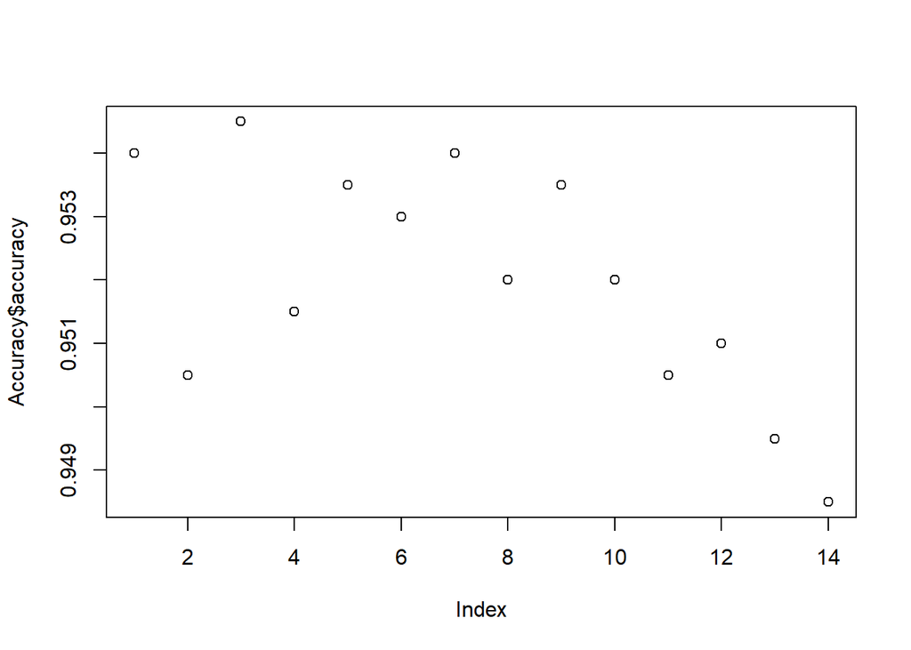

```r
plot(Accuracy$accuracy)
```

#Answer for Q2: The algorithm worked best with k=3. Using our current data (60% training, 40% validation), k=3 seems to give a good balance between overfitting and underfitting

#### 3. Show the confusion matrix for the validation data that results from using the best k.

```r
Pred.Model2<-knn(Train_Predictors, Validation_Predictors, cl=Train_Label,k=3)
CrossTable(x=Validation_Label,y= Pred.Model2, prop.chisq = FALSE)
```

```
##
##
##    Cell Contents
## |-------------------------|
## |                       N |
## |           N / Row Total |
## |           N / Col Total |
## |         N / Table Total |
## |-------------------------|
##
##
## Total Observations in Table:  2000
##
##
##                  | Pred.Model2
## Validation_Label |      Fail |   Success | Row Total |
## -----------------|-----------|-----------|-----------|
##             Fail |      1790 |        18 |      1808 |
##                  |     0.990 |     0.010 |     0.904 |
##                  |     0.961 |     0.131 |           |
##                  |     0.895 |     0.009 |           |
## -----------------|-----------|-----------|-----------|
##          Success |        73 |       119 |       192 |
##                  |     0.380 |     0.620 |     0.096 |
##                  |     0.039 |     0.869 |           |
##                  |     0.036 |     0.059 |           |
## -----------------|-----------|-----------|-----------|
##     Column Total |      1863 |       137 |      2000 |
##                  |     0.931 |     0.068 |           |
## -----------------|-----------|-----------|-----------|
##
##
```

```r
confusionMatrix(Pred.Model2,Validation_Label)
```

```
## Confusion Matrix and Statistics
##
##           Reference
## Prediction Fail Success
##    Fail    1790      73
##    Success   18     119
##
##                Accuracy : 0.9545
##                  95% CI : (0.9444, 0.9632)
##     No Information Rate : 0.904
##     P-Value [Acc > NIR] : < 2.2e-16
##
##                   Kappa : 0.6994
##
##  Mcnemar's Test P-Value : 1.507e-08
##
##             Sensitivity : 0.9900
##             Specificity : 0.6198
##          Pos Pred Value : 0.9608
##          Neg Pred Value : 0.8686
##              Prevalence : 0.9040
##          Detection Rate : 0.8950
##    Detection Prevalence : 0.9315
##       Balanced Accuracy : 0.8049
##
##        'Positive' Class : Fail
##
```

#Answer for Q3: The confusion matrix for k=3 showed an accuracy of 0.9545, meaning about 95.45% of the loan acceptance predictions were correct, while roughly 4.55% were misclassified

#### 4. Consider the following customer: Age = 40, Experience = 10, Income = 84, Family = 2, CCAvg = 2, Education_1 = 0, Education_2 = 1, Education_3 = 0, Mortgage = 0, Securities Account = 0, CD Account = 0, Online = 1 and Credit Card = 1. Classify the customer using the best k.

#best k was 3 with the highest accuracy so

```r
#Evaluation of the New Person using the best k=3
Pred.Applicant <- knn(Train_Predictors, Applicant_Predictors, cl=Train_Label, k=3, prob=TRUE)
attributes(Pred.Applicant)
```

```
## $levels
## [1] "Fail"    "Success"
##
## $class
## [1] "factor"
##
## $prob
## [1] 1
```

```r
Result2<-data.frame(Pred.Applicant)
Result2
```

```
##   Pred.Applicant
## 1           Fail
```

```r
head(Pred.Applicant)
```

```
## [1] Fail
## Levels: Fail Success
```